# assign1_kat_leigh_part2

Kat Leigh

1/20/2021

This data set contains the difference between an observed (historical, from 1956 - 2020) or predicted (future, from 2010 - 2020) value for an aquatic parameter (i.e. temperature, salinity, dissolved oxygen, or pH) and an ideal value for that parameter. These ideal values were determined by averaging the values recommended by scientific literature for each life stage (i.e. egg, zoea, megalopae, juvenile, and adult) of Blue Swimming Crab (Portunus armatus, formerly Portunus pelagicus). The differences were normalized across all depths (surface, 30m, 100m, and bottom), time periods, and parameters. The question at hand is whether latitude/longitude and the normalized differences per parameter are correlated in some way to each other and/or to the life stages.

```r
# read in the data

normdiffs_depth_lifestage_time_param <- read.csv("C:/Users/kll86/OneDrive/EDF internship summer 2020/NC_files/mean_alldepths_allstage_allparam_histfut_norm_diffs.csv")
```

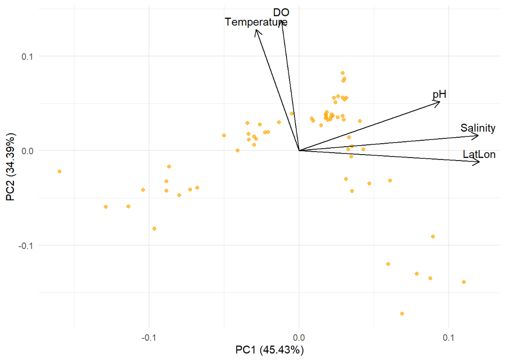

```r
# set the proper classes for the data to run a PCA

normdiffs <- normdiffs_depth_lifestage_time_param %>%
  mutate(depth = as.numeric(depth),
         time = as.numeric(time),
         lifestage = as.factor(lifestage),
         parameter = as.factor(parameter))

# only select the historical data and the life stage, parameter, normalized differences, and latitude / longitude pairs to run the analysis. also shrink dataset to allow local processing w/ R.

normdiffs_hist <- normdiffs %>%
  filter(time == 2,
         lat > 15,
         lon > 85,
         depth == 1) %>%
  select(lifestage,parameter, lat, lon, norm_diff)

#remove the larger files to free up space

remove("normdiffs")

# combine the latitude and longitude values into a single combination value that represents both numbers. Add 180 to these values before summing to get rid of negative values.

normdiffs_hist_combo <- normdiffs_hist %>%
  mutate(latlon = ((lat+180)+(lon+180))) %>%
  mutate(latlon = round(latlon, 0)) %>%
  group_by(latlon, lifestage, parameter) %>%
  summarise(norm_diff_new = mean(norm_diff)) %>%
  ungroup()

#remove a large file to free up space

remove("normdiffs_hist")

# compare the 4 parameters by seperating the differences by parameter

wider_diffs <- normdiffs_hist_combo %>%
  pivot_wider(names_from = parameter, values_from = norm_diff_new) %>%
  drop_na()
names(wider_diffs) <- c("LatLon", "Life Stage", "DO", "pH", "Salinity", "Temperature")

# Conduct a PCA. First just select the numerical inputs to compare (latlon and norm_diff). Then, scale these values. Finally run a PCA.

normdiff_pca_hist_c <- wider_diffs %>%
  dplyr::select(LatLon, DO, Temperature, pH, Salinity) %>%
  scale() %>%
  prcomp()

# plot the outputs of the PCA. categorize the data by life stage (shape of points).

diffs_plot <- autoplot(normdiff_pca_hist_c,
         data = wider_diffs,
         loadings = TRUE,
        # shape = 'lifestage', note: this is removed because the data currently do not have any differences per life stage
         colour = "orange",
         alpha = .2,
         loadings.label = TRUE,
         loadings.colour = "black",
         loadings.label.colour = "black",
         loadings.label.vjust = -0.5
         ) +  theme_minimal()


diffs_plot
```

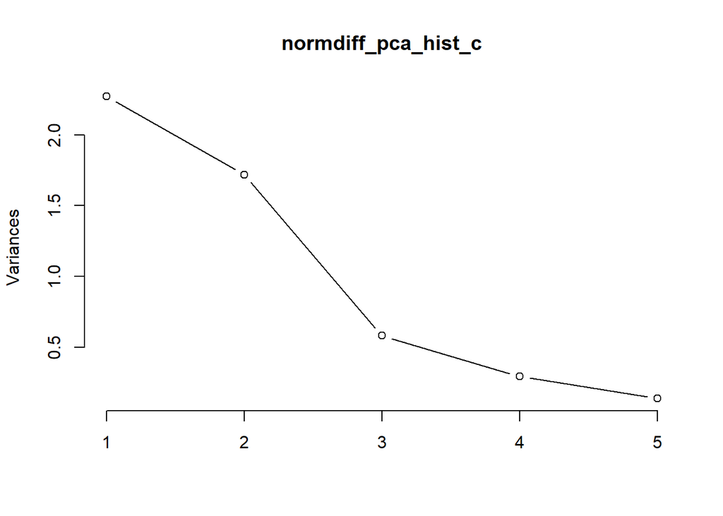

```r
# Variance explained by each PC
scree_diffs <- screeplot(normdiff_pca_hist_c, type = "lines")
```

```r
# See the loadings (weighting for each principal component)
weightings <- normdiff_pca_hist_c$rotation

weightings
```

```
##                     PC1         PC2        PC3         PC4        PC5
## LatLon       0.61310824 -0.06083529  0.3488911 -0.08608078  0.7009011
## DO          -0.06095386  0.70277454 -0.1497463  0.63913356  0.2673517
## Temperature -0.14594532  0.65309180  0.4514064 -0.57962341 -0.1115348
## pH           0.47798040  0.26308288 -0.7401239 -0.38603449 -0.0742708
## Salinity     0.60878371  0.08164257  0.3229549  0.31482133 -0.6475373
```

We find that the normalized differences of Temperature and Dissolved Oxygen are closely correlated, and that of pH and Salinity are somewhat correlated to each other as well as the combo Lat/Lon values. This has interesting implications to the relationships between these aquatic parameters to each other as well as oceanic location. Important, however, is to note the wide dispersion of the data points themselves. Trends are not very pronounced.

A more appropriate analysis to examine how the normalized difference is affected would be to run multiple regressions. The predictor variables that would be tested in this case are lat/lon, depth, time, and life stage.